# Statistics

## Statistics

Now we are going to cover how to perform a variety of basic statistical tests in R.

- Correlation
- T-tests/Rank-sum tests
- Linear Regression
- Logistic Regression
- Proportion tests
- Chi-squared
- Fisher's Exact Test

Note: We will be glossing over the statistical theory and "formulas" for these tests. There are plenty of resources online for learning more about these tests, as well as dedicated Biostatistics series at the School of Public Health

## Correlation

`cor()` performs correlation in R

```
cor(x, y = NULL, use = "everything",
    method = c("pearson", "kendall", "spearman"))
```

Like other functions, if there are NAs, you get NA as the result. But if you specify use only the complete observations, then it will give you correlation on the non-missing data.

```r
> library(readr)
> circ = read_csv("http://www.aejaffe.com/winterR_2017/data/Charm_City_Circulator_Ridership.csv")
> cor(circ$orangeAverage, circ$purpleAverage, use="complete.obs")
```

```
[1] 0.9195356
```

## Correlation

You can also get the correlation between matrix columns

```r
> library(dplyr)
> avgs = circ %>% select(ends_with("Average"))
> avgs_cor = cor(avgs, use = "complete.obs")
> signif(avgs_cor,3)
```

```
              orangeAverage purpleAverage greenAverage bannerAverage
orangeAverage         1.000         0.908        0.840         0.545
purpleAverage         0.908         1.000        0.867         0.521
greenAverage          0.840         0.867        1.000         0.453
bannerAverage         0.545         0.521        0.453         1.000
```

## Correlation

You can also get the correlation between matrix columns

Or between columns of two matrices/dfs, column by column.

```r
> op = avgs %>% select(orangeAverage, purpleAverage)
> gb = avgs %>% select(greenAverage, bannerAverage)
> signif(cor(op, gb, use = "complete.obs"), 3)
```

```
              greenAverage bannerAverage
orangeAverage        0.840         0.545
purpleAverage        0.867         0.521
```

## Correlation

You can also use `cor.test()` to test for whether correlation is significant (ie non-zero). Note that linear regression may be better, especially if you want to regress out other confounders.

```r
> ct = cor.test(circ$orangeAverage, circ$purpleAverage,
+               use = "complete.obs")
> ct
```

```
    Pearson's product-moment correlation

data:  circ$orangeAverage and circ$purpleAverage
t = 73.656, df = 991, p-value < 2.2e-16
alternative hypothesis: true correlation is not equal to 0
95 percent confidence interval:
 0.9093438 0.9286245
sample estimates:
      cor
0.9195356
```

## Correlation

For many of these testing result objects, you can extract specific slots/results as numbers, as the `ct` object is just a list.

```r
> # str(ct)
> names(ct)
```

```
[1] "statistic"   "parameter"   "p.value"     "estimate"    "null.value"
[6] "alternative" "method"      "data.name"   "conf.int"
```

```r
> ct$statistic
```

```
       t
73.65553
```

```r
> ct$p.value
```

```
[1] 0
```

## Broom package

The `broom` package has a `tidy` function that puts most objects into `data.frame`s so that they are easily manipulated:

```r
> library(broom)
> tidy_ct = tidy(ct)
> tidy_ct
```

```
   estimate statistic p.value parameter  conf.low conf.high
1 0.9195356  73.65553       0       991 0.9093438 0.9286245
                                method alternative
1 Pearson's product-moment correlation   two.sided
```

## Correlation

Note that you can add the correlation to a plot, via the legend() function.

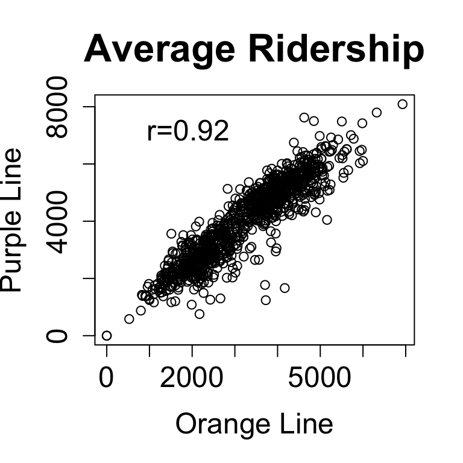

```r
> txt = paste0("r=", signif(ct$estimate,3))
> plot(circ$orangeAverage, circ$purpleAverage,
+      xlab="Orange Line", ylab="Purple Line",
+      main="Average Ridership",cex.axis=1.5,
+      cex.lab=1.5,cex.main=2)
> legend("topleft", txt, bty="n",cex=1.5)
```

## Correlation

Or with the `annotate` command in `ggplot2

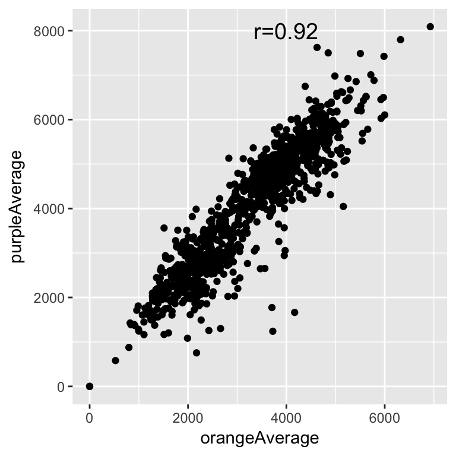

```r
> library(ggplot2)
> q = qplot(data = circ, x = orangeAverage, y = purpleAverage)
> q + annotate("text", x = 4000, y = 8000, label = txt, size = 5)
```

## T-tests

The T-test is performed using the `t.test()` function, which essentially tests for the difference in means of a variable between two groups.

In this syntax, x and y are the column of data for each group.

```r
> tt = t.test(circ$orangeAverage, circ$purpleAverage)
> tt
```

```
    Welch Two Sample t-test

data:  circ$orangeAverage and circ$purpleAverage
t = -17.076, df = 1984, p-value < 2.2e-16
alternative hypothesis: true difference in means is not equal to 0
95 percent confidence interval:
 -1096.7602  -870.7867
sample estimates:
mean of x mean of y
 3033.161  4016.935
```

## T-tests

`t.test` saves a lot of information: the difference in means `estimate`, confidence interval for the difference `conf.int`, the p-value `p.value`, etc.

```r
> names(tt)
```

```
[1] "statistic"   "parameter"   "p.value"     "conf.int"    "estimate"
[6] "null.value"  "alternative" "method"      "data.name"
```

## T-tests

```r
> tidy(tt)
```

```
   estimate estimate1 estimate2 statistic      p.value parameter conf.low
1 -983.7735  3033.161  4016.935 -17.07579 4.201155e-61  1983.954 -1096.76
  conf.high                  method alternative
1 -870.7867 Welch Two Sample t-test   two.sided
```

## T-tests

You can also use the 'formula' notation. In this syntax, it is `y ~ x`, where `x` is a factor with 2 levels or a binary variable and `y` is a vector of the same length.

```r
library(tidyr)
long = circ %>%
  select(date, orangeAverage, purpleAverage) %>%
  gather(key = line, value = avg, -date)
tt = t.test(avg ~ line, data = long)
tidy(tt)
```

```
   estimate estimate1 estimate2 statistic      p.value parameter conf.low
1 -983.7735  3033.161  4016.935 -17.07579 4.201155e-61  1983.954 -1096.76
  conf.high                  method alternative
1 -870.7867 Welch Two Sample t-test   two.sided
```

## Wilcoxon Rank-Sum Tests

Nonparametric analog to t-test (testing medians):

```r
> tidy(wilcox.test(avg ~ line, data = long))
```

```
  statistic     p.value                                            method
1  336713.5 4.55641e-58 Wilcoxon rank sum test with continuity correction
  alternative
1   two.sided
```

## Linear Regression

Now we will briefly cover linear regression. I will use a little notation here so some of the commands are easier to put in the proper context. \[ y_i = \alpha + \beta x_i + \varepsilon_i \] where:

- \(y_i\) is the outcome for person i
- \(\alpha\) is the intercept
- \(\beta\) is the slope
- \(x_i\) is the predictor for person i
- \(\varepsilon_i\) is the residual variation for person i

## Linear Regression

The `R` version of the regression model is:

```
y ~ x
```

where:

- y is your outcome
- x is/are your predictor(s)

## Linear Regression

For a linear regression, when the predictor is binary this is the same as a t-test:

```r
> fit = lm(avg ~ line, data = long)
> fit
```

```
Call:
lm(formula = avg ~ line, data = long)

Coefficients:
      (Intercept)  linepurpleAverage
           3033.2              983.8
```

'(Intercept)' is \(\alpha\)

'linepurpleAverage' is \(\beta\)

## Linear Regression

The `summary` command gets all the additional information (p-values, t-statistics, r-square) that you usually want from a regression.

```r
> sfit = summary(fit)
> print(sfit)
```

```
Call:
lm(formula = avg ~ line, data = long)

Residuals:
    Min      1Q  Median      3Q     Max
-4016.9 -1121.2    64.3  1060.8  4072.6

Coefficients:
                  Estimate Std. Error t value Pr(>|t|)
(Intercept)        3033.16      38.99   77.79   <2e-16 ***
linepurpleAverage   983.77      57.09   17.23   <2e-16 ***
---
Signif. codes:  0 '***' 0.001 '**' 0.01 '*' 0.05 '.' 0.1 ' ' 1

Residual standard error: 1314 on 2127 degrees of freedom
  (163 observations deleted due to missingness)
Multiple R-squared:  0.1225,    Adjusted R-squared:  0.1221
F-statistic: 296.9 on 1 and 2127 DF,  p-value: < 2.2e-16
```

## Linear Regression

The coefficients from a `summary` are the coefficients, standard errors, t-statistcs, and p-values for all the estimates.

```r
> names(sfit)
```

```
 [1] "call"          "terms"         "residuals"     "coefficients"
 [5] "aliased"       "sigma"         "df"            "r.squared"
 [9] "adj.r.squared" "fstatistic"    "cov.unscaled"  "na.action"
```

```r
> sfit$coef
```

```
                   Estimate Std. Error  t value     Pr(>|t|)
(Intercept)       3033.1611   38.98983 77.79365 0.000000e+00
linepurpleAverage  983.7735   57.09059 17.23180 2.163655e-62
```

## Linear Regression

We can `tidy` linear models as well and it gives us all of this in one::

```r
> tidy(fit)
```

```
               term  estimate std.error statistic      p.value
1       (Intercept) 3033.1611  38.98983  77.79365 0.000000e+00
2 linepurpleAverage  983.7735  57.09059  17.23180 2.163655e-62
```

## Using Cars Data

```r
> http_data_dir = "http://www.aejaffe.com/winterR_2017/data/"
> cars = read_csv(paste0(http_data_dir, "kaggleCarAuction.csv"))
```

## Linear Regression

We'll look at vehicle odometer value by vehicle age:

```r
fit = lm(VehOdo~VehicleAge, data = cars)
print(fit)
```

```
Call:
lm(formula = VehOdo ~ VehicleAge, data = cars)

Coefficients:
(Intercept)   VehicleAge
      60127         2723
```

## Linear Regression

We can visualize the vehicle age/odometer relationshp using scatter plots or box plots (with regression lines). The function `abline` will plot the regresion line on the plot.

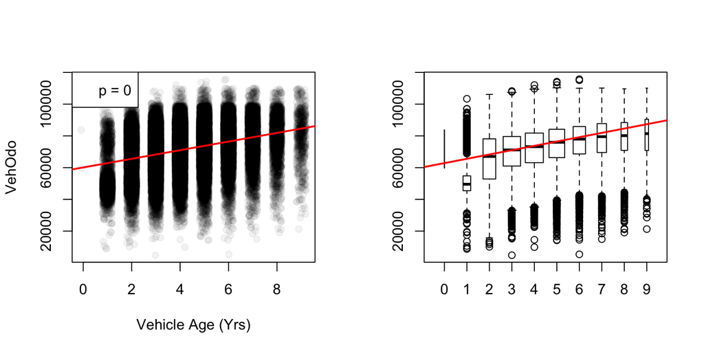

```r
> par(mfrow=c(1,2))
> plot(VehOdo ~ jitter(VehicleAge,amount=0.2), data=cars, pch = 19,
+      col = scales::alpha("black",0.05), xlab = "Vehicle Age (Yrs)")
> abline(fit, col = "red",lwd=2)
> legend("topleft", paste("p =",summary(fit)$coef[2,4]))
> boxplot(VehOdo ~ VehicleAge, data=cars, varwidth=TRUE)
> abline(fit, col="red",lwd=2)
```

## Linear Regression: adding line with ggplot2

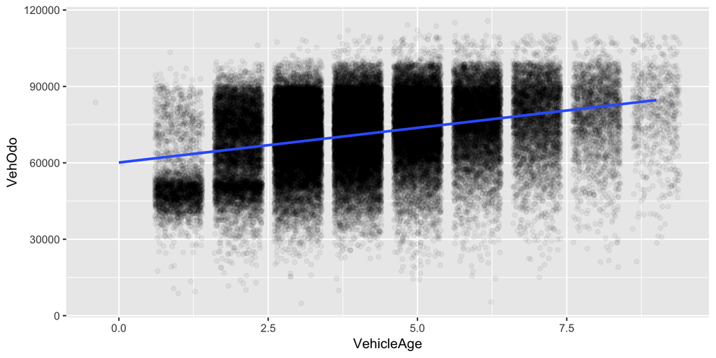

```r
> g = ggplot(aes(x = VehicleAge, y = VehOdo), data = cars) +
+   geom_jitter(alpha = 0.05, height = 0) +
+   geom_smooth(se = FALSE, method = "lm")
> print(g)
```

## Linear Regression

```r
> fit2 = lm(VehOdo ~ IsBadBuy + VehicleAge, data = cars)
> summary(fit2)
```

```
Call:
lm(formula = VehOdo ~ IsBadBuy + VehicleAge, data = cars)

Residuals:
   Min     1Q Median     3Q    Max
-70856  -9490   1390  10311  41193

Coefficients:
            Estimate Std. Error t value Pr(>|t|)
(Intercept) 60141.77     134.75  446.33   <2e-16 ***
IsBadBuy     1329.00     157.84    8.42   <2e-16 ***
VehicleAge   2680.33      30.27   88.53   <2e-16 ***
---
Signif. codes:  0 '***' 0.001 '**' 0.01 '*' 0.05 '.' 0.1 ' ' 1

Residual standard error: 13810 on 72980 degrees of freedom
Multiple R-squared:  0.1031,    Adjusted R-squared:  0.1031
F-statistic:  4196 on 2 and 72980 DF,  p-value: < 2.2e-16
```

## Linear Regression

Added-Variable plots can show you the relationship between a variable and outcome after adjusting for other variables. The function `avPlots` from the `car` package can do this:

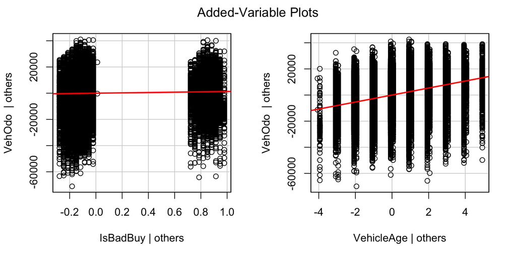

```r
> library(car)
> avPlots(fit2)
```

## Linear Regression

Plot on an `lm` object will do diagnostic plots. Residuals vs. Fitted should have no discernable shape (the red line is the smoother), the qqplot shows how well the residuals fit a normal distribution, and Cook's distance measures the influence of individual points.

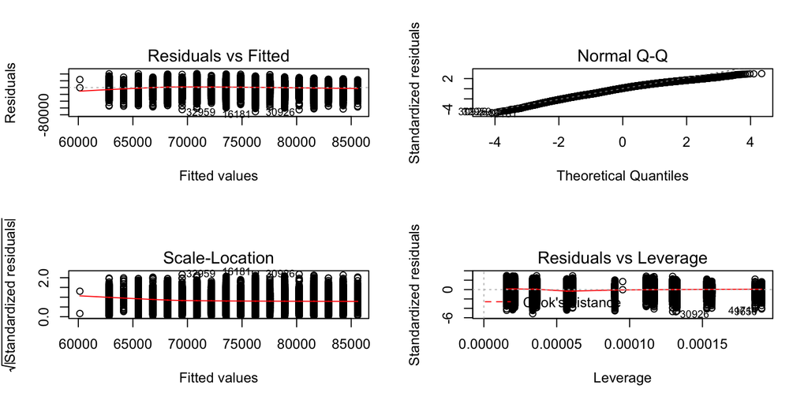

```r
> par(mfrow=c(2,2))
> plot(fit2, ask = FALSE)
```

## Linear Regression

Factors get special treatment in regression models - lowest level of the factor is the comparison group, and all other factors are relative to its values.

```r
> fit3 = lm(VehOdo ~ factor(TopThreeAmericanName), data = cars)
> summary(fit3)
```

```
Call:
lm(formula = VehOdo ~ factor(TopThreeAmericanName), data = cars)

Residuals:
   Min     1Q Median     3Q    Max
-71947  -9634   1532  10472  45936

Coefficients:
                                  Estimate Std. Error t value Pr(>|t|)
(Intercept)                       68248.48      92.98 733.984  < 2e-16 ***
factor(TopThreeAmericanName)FORD   8523.49     158.35  53.828  < 2e-16 ***
factor(TopThreeAmericanName)GM     4952.18     128.99  38.393  < 2e-16 ***
factor(TopThreeAmericanName)NULL  -2004.68    6361.60  -0.315 0.752670
factor(TopThreeAmericanName)OTHER   584.87     159.92   3.657 0.000255 ***
---
Signif. codes:  0 '***' 0.001 '**' 0.01 '*' 0.05 '.' 0.1 ' ' 1

Residual standard error: 14220 on 72978 degrees of freedom
Multiple R-squared:  0.04822,   Adjusted R-squared:  0.04817
F-statistic: 924.3 on 4 and 72978 DF,  p-value: < 2.2e-16
```

## Logistic Regression and GLMs

Generalized Linear Models (GLMs) allow for fitting regressions for non-continous/normal outcomes. The `glm` has similar syntax to the `lm` command. Logistic regression is one example.

```r
> glmfit = glm(IsBadBuy ~ VehOdo + VehicleAge, data=cars, family = binomial())
> summary(glmfit)
```

```
Call:
glm(formula = IsBadBuy ~ VehOdo + VehicleAge, family = binomial(),
    data = cars)

Deviance Residuals:
    Min       1Q   Median       3Q      Max
-0.9943  -0.5481  -0.4534  -0.3783   2.6318

Coefficients:
              Estimate Std. Error z value Pr(>|z|)
(Intercept) -3.778e+00  6.381e-02 -59.211   <2e-16 ***
VehOdo       8.341e-06  8.526e-07   9.783   <2e-16 ***
VehicleAge   2.681e-01  6.772e-03  39.589   <2e-16 ***
---
Signif. codes:  0 '***' 0.001 '**' 0.01 '*' 0.05 '.' 0.1 ' ' 1

(Dispersion parameter for binomial family taken to be 1)

    Null deviance: 54421  on 72982  degrees of freedom
Residual deviance: 52346  on 72980  degrees of freedom
AIC: 52352

Number of Fisher Scoring iterations: 5
```

## Tidying GLMs

```r
> tidy(glmfit)
```

```
         term      estimate    std.error  statistic      p.value
1 (Intercept) -3.778229e+00 6.380920e-02 -59.211349 0.000000e+00
2      VehOdo  8.341015e-06 8.526052e-07   9.782975 1.332358e-22
3  VehicleAge  2.681086e-01 6.772236e-03  39.589373 0.000000e+00
```

## Logistic Regression

```r
> exp(coef(glmfit))
```

```
(Intercept)      VehOdo  VehicleAge
 0.02286316  1.00000834  1.30748911
```

## Proportion tests

`prop.test()` can be used for testing the null that the proportions (probabilities of success) in several groups are the same, or that they equal certain given values.

```
prop.test(x, n, p = NULL,
          alternative = c("two.sided", "less", "greater"),
          conf.level = 0.95, correct = TRUE)
```

```r
> prop.test(x = 15, n =32)
```

```
    1-sample proportions test with continuity correction

data:  15 out of 32, null probability 0.5
X-squared = 0.03125, df = 1, p-value = 0.8597
alternative hypothesis: true p is not equal to 0.5
95 percent confidence interval:
 0.2951014 0.6496695
sample estimates:
      p
0.46875
```

## Chi-squared tests

`chisq.test()` performs chi-squared contingency table tests and goodness-of-fit tests.

```
chisq.test(x, y = NULL, correct = TRUE,
           p = rep(1/length(x), length(x)), rescale.p = FALSE,
           simulate.p.value = FALSE, B = 2000)
```

```r
> tab = table(cars$IsBadBuy, cars$IsOnlineSale)
> tab
```

```
        0     1
  0 62375  1632
  1  8763   213
```

## Chi-squared tests

You can also pass in a table object (such as `tab` here)

```r
> cq = chisq.test(tab)
> cq
```

```
    Pearson's Chi-squared test with Yates' continuity correction

data:  tab
X-squared = 0.92735, df = 1, p-value = 0.3356
```

```r
> names(cq)
```

```
[1] "statistic" "parameter" "p.value"   "method"    "data.name" "observed"
[7] "expected"  "residuals" "stdres"
```

```r
> cq$p.value
```

```
[1] 0.3355516
```

## Chi-squared tests

Note that does the same test as `prop.test`, for a 2x2 table (`prop.test` not relevant for greater than 2x2).

```r
> chisq.test(tab)
```

```
    Pearson's Chi-squared test with Yates' continuity correction

data:  tab
X-squared = 0.92735, df = 1, p-value = 0.3356
```

```r
> prop.test(tab)
```

```
    2-sample test for equality of proportions with continuity
    correction

data:  tab
X-squared = 0.92735, df = 1, p-value = 0.3356
alternative hypothesis: two.sided
95 percent confidence interval:
 -0.005208049  0.001673519
sample estimates:
   prop 1    prop 2
0.9745028 0.9762701
```

## Fisher's Exact test

`fisher.test()` performs contingency table test using the hypogeometric distribution (used for small sample sizes).

```
fisher.test(x, y = NULL, workspace = 200000, hybrid = FALSE,
            control = list(), or = 1, alternative = "two.sided",
            conf.int = TRUE, conf.level = 0.95,
            simulate.p.value = FALSE, B = 2000)
```

```r
> fisher.test(tab)
```

```
    Fisher's Exact Test for Count Data

data:  tab
p-value = 0.3324
alternative hypothesis: true odds ratio is not equal to 1
95 percent confidence interval:
 0.8001727 1.0742114
sample estimates:
odds ratio
 0.9289923
```

## Probability Distributions

Sometimes you want to generate data from a distribution (such as normal), or want to see where a value falls in a known distribution. `R` has these distibutions built in:

- Normal
- Binomial
- Beta
- Exponential
- Gamma
- Hypergeometric
- etc

## Probability Distributions

Each has 4 options:

- `r` for random number generation [e.g. `rnorm()`]
- `d` for density [e.g. `dnorm()`]
- `p` for probability [e.g. `pnorm()`]
- `q` for quantile [e.g. `qnorm()`]

```r
> rnorm(5)
```

```
[1]  0.2773439  0.9714192 -0.1237692 -0.7076843 -1.7623573
```

## Sampling

The `sample()` function is pretty useful for permutations

```r
> sample(1:10, 5, replace=FALSE)
```

```
[1] 2 8 1 5 3
```

## Sampling

Also, if you want to only plot a subset of the data (for speed/time or overplotting)

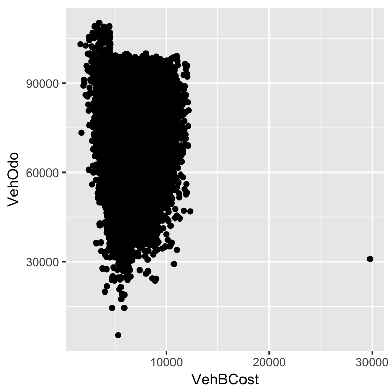

```r
> samp.cars <- cars[ sample(nrow(cars), 10000), ]
> samp.cars = dplyr::sample_n(cars, size = 10000)
> samp.cars = dplyr::sample_frac(cars, size = 0.2)
> ggplot(aes(x = VehBCost, y = VehOdo),
+        data = samp.cars) + geom_point()
```